# Panel Regression

Dhrubasattwata Roy Choudhury

12/07/2020

## Panel Regression

Panel data, along with cross-sectional and time series data, are the main data types that we encounter when working with regression analysis. When it comes to panel data, standard regression analysis often falls short in isolating fixed and random effects.

Types of data 1. Cross-Sectional: Data collected at one particular point in time 2. Time Series: Data collected across several time periods 3. Panel Data: A mixture of both cross-sectional and time series data, i.e. collected at a particular point in time and across several time periods

Types of Panel Regression: 1. Fixed Effects: Effects that are independent of random disturbances, e.g. observations independent of time. 2. Random Effects: Effects that include random disturbances.

### Dataset

For this tutorial, we are going to use a dataset of weekly internet usage in MB across 33 weeks across three different companies (A, B, and C). Download it from here: Github Repo

```r
mydata <- read.csv("C:/Users/Dhruba/Documents/R/data/internetplm.csv")
head(mydata)
```

```
##   week company age gender webpages videohours income usage
## 1    1       a  28      0       79 12.0183333   7995 29770
## 2    2       a  53      1       13  0.0000000   6309  2228
## 3    3       a  21      1       23  2.6411111   4866  3014
## 4    4       a  49      1       26  0.9919444   5246  6191
## 5    5       a  55      1       45  7.9686111   9148 18997
## 6    6       a  46      1       21  0.0000000      0  1358
```

### Setting up the Fixed Effects Model

```r
library(plm)
plmwithin <- plm(usage~income+videohours+webpages+gender+age, data = mydata, model = "within")
summary(plmwithin)
```

```
## Oneway (individual) effect Within Model
##
## Call:
## plm(formula = usage ~ income + videohours + webpages + gender +
##     age, data = mydata, model = "within")
##
## Balanced Panel: n = 33, T = 3, N = 99
##
## Residuals:
##      Min.   1st Qu.    Median   3rd Qu.      Max.
## -7001.684 -1744.973   -18.793  1212.604  6423.064
##
## Coefficients:
##               Estimate  Std. Error t-value  Pr(>|t|)
## income         0.60389     0.14897  4.0538 0.0001451 ***
## videohours  1261.43899   111.13253 11.3508 < 2.2e-16 ***
## webpages      97.79839    42.06834  2.3248 0.0234299 *
## gender     -1328.98316   812.05060 -1.6366 0.1068685
## age           54.15710    36.54555  1.4819 0.1435128
## ---
## Signif. codes:  0 '***' 0.001 '**' 0.01 '*' 0.05 '.' 0.1 ' ' 1
##
## Total Sum of Squares:    4312700000
## Residual Sum of Squares: 692730000
## R-Squared:      0.83937
## Adj. R-Squared: 0.74195
## F-statistic: 63.7531 on 5 and 61 DF, p-value: < 2.22e-16
```

### Setting up the Random Effects Model

```r
plmrandom <- plm(usage~income+videohours+webpages+gender+age, data = mydata, model = "random")
summary(plmrandom)
```

```
## Oneway (individual) effect Random Effect Model
##    (Swamy-Arora's transformation)
##
## Call:
## plm(formula = usage ~ income + videohours + webpages + gender +
##     age, data = mydata, model = "random")
##
## Balanced Panel: n = 33, T = 3, N = 99
##
## Effects:
##                    var  std.dev share
## idiosyncratic 11356210     3370 0.906
## individual     1174165     1084 0.094
## theta: 0.1264
##
## Residuals:
##      Min.   1st Qu.    Median   3rd Qu.      Max.
## -8145.368 -1814.514   -88.599  2091.355  8488.988
##
## Coefficients:
##                Estimate  Std. Error z-value  Pr(>|z|)
## (Intercept) -1839.90828  1482.27056 -1.2413   0.21450
## income          0.51520     0.12415  4.1497 3.329e-05 ***
## videohours   1265.09361    94.02028 13.4555 < 2.2e-16 ***
## webpages       95.38905    37.67569  2.5318   0.01135 *
## gender      -1683.98846   708.09778 -2.3782   0.01740 *
## age            57.25917    30.01035  1.9080   0.05639 .
## ---
## Signif. codes:  0 '***' 0.001 '**' 0.01 '*' 0.05 '.' 0.1 ' ' 1
##
## Total Sum of Squares:    5766200000
## Residual Sum of Squares: 1026500000
## R-Squared:      0.82198
## Adj. R-Squared: 0.81241
## Chisq: 429.407 on 5 DF, p-value: < 2.22e-16
```

In the case of the first regression, the regression is accounting for fixed effects (or internet usage independent of time), while the second is accounting for random effects (including time). Note that the variables gender and age which were deemed insigificant in the fixed effects regression are now being deemed significant in the random effects regression.

### Fixed Effects regression: Further Analysis

Analysing with fixef to isolate the effects of time on internet usage.

```r
#Effect of time on internet usage
fixef(plmwithin,type="dmean")
```

```
##         1         2         3         4         5         6         7         8
##  3054.605  -467.630 -1557.955   524.949   -18.386 -1374.685  2300.643  1890.253
##         9        10        11        12        13        14        15        16
##  -541.150  4721.513   241.624 -1438.665  2208.144 -2036.572  -848.015   508.110
##        17        18        19        20        21        22        23        24
##  -269.416  2335.414   803.855 -3633.564 -1399.482  2142.245   258.546 -2458.990
##        25        26        27        28        29        30        31        32
## -1724.920 -3979.098    70.255   717.642  1289.951 -1763.476  2241.485  2945.158
##        33
## -4742.387
```

```r
summary(fixef(plmwithin, type = "dmean"))
```

```
##     Estimate Std. Error t-value Pr(>|t|)
## 1   3054.605   2860.669  1.0678  0.28982
## 2   -467.630   2452.521 -0.1907  0.84941
## 3  -1557.955   2368.244 -0.6579  0.51311
## 4    524.949   2734.229  0.1920  0.84839
## 5    -18.386   2861.050 -0.0064  0.99489
## 6  -1374.685   2719.298 -0.5055  0.61501
## 7   2300.643   2353.954  0.9774  0.33225
## 8   1890.253   2598.290  0.7275  0.46970
## 9   -541.150   2518.805 -0.2148  0.83061
## 10  4721.513   2619.317  1.8026  0.07640 .
## 11   241.624   2765.534  0.0874  0.93066
## 12 -1438.665   2868.905 -0.5015  0.61785
## 13  2208.144   2651.892  0.8327  0.40828
## 14 -2036.572   2549.967 -0.7987  0.42758
```

[output cut: 21 more lines]

Observe that weeks 10 and 33 are significant at the 10% level. Looking at the data

```r
df <- mydata[mydata$week== 10,]
df <- df[,c("week", "usage")]
df
```

```
##    week usage
## 10   10 25182
## 43   10 20011
## 76   10 19990
```

For week 10, we see that usage across A, B, and C is higher than usual

```r
df <- mydata[mydata$week== 33,]
df <- df[,c("week", "usage")]
df
```

```
##    week usage
## 33   33  4793
## 66   33  2977
## 99   33  3698
```

This could indicate that something is taking place across these particular weeks to cause internet usage to be higher and lower than usual. We see that using fixef has allowed us to isolate the effect of time in this regard.

Now, let us extract fixed effects – i.e. effects independent of time.

```r
twoway <-  plm(usage~income+videohours+webpages+gender+age+company,data=mydata,model="within",effect="time")
fixef(twoway,effect="time")
```

```
##        a        b        c
##  -451.36 -1202.34 -3451.64
```

We see that of the three internet companies, company C has the largest negative coefficient.

Subset usage for the three companies and see what is going on:

```r
a <- subset(mydata, company=="a")
b <- subset(mydata, company=="b")
c <- subset(mydata, company=="c")

mean(a$usage)
```

```
## [1] 11646.94
```

```r
mean(b$usage)
```

```
## [1] 8851.848
```

```r
mean(c$usage)
```

```
## [1] 6279.03
```

We see that mean internet usage for company C is lower than that of A and B.

# Visualization for better understanding

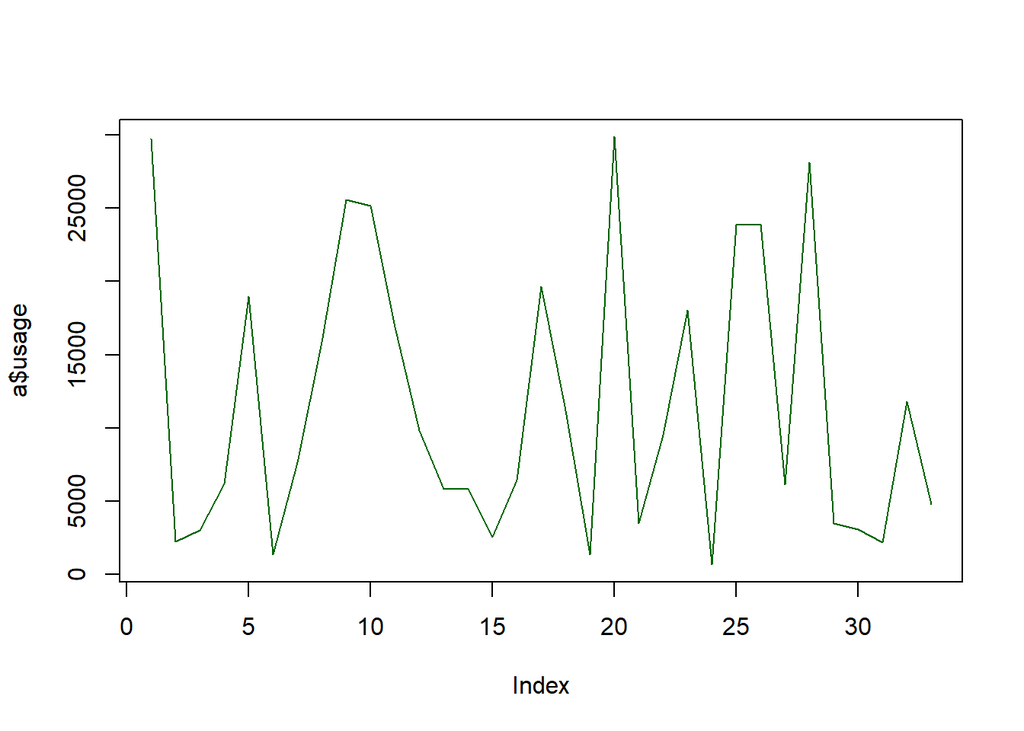

```r
plot(a$usage,type='l')
lines(a$usage, col="darkgreen")
```

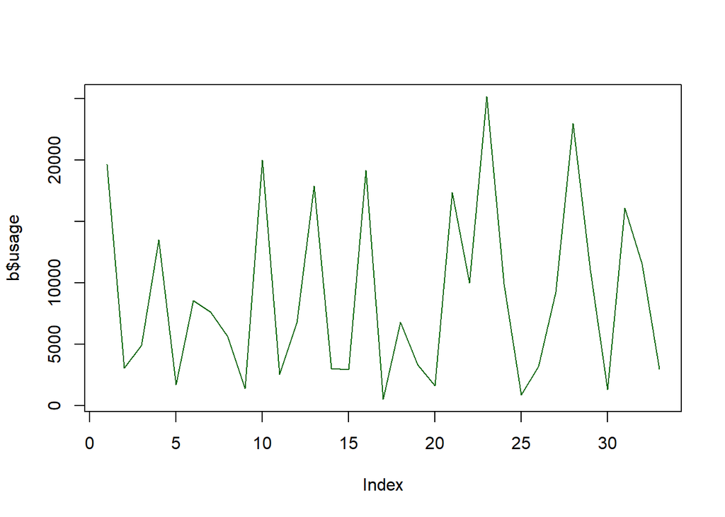

```r
plot(b$usage,type='l')
lines(b$usage, col="darkgreen")
```

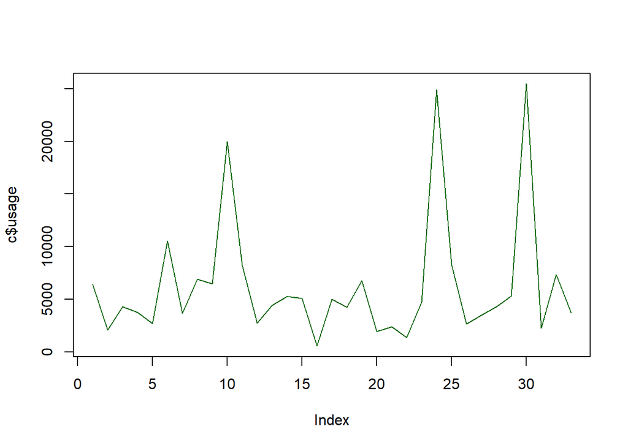

```r
plot(c$usage,type='l')
lines(c$usage, col="darkgreen")
```

We see that in the case of C, usage remains low overall but there are certain periods where we see a spike in usage. However, we see these spikes much more frequently for A and B.

In this regard, comparing fixed and random effects has allowed us to isolate the impact of time on usage patterns for C.